# Project

Mukta, Suman, Reshma

3/22/2018

## Introduction :

As crime rate in chicago observed more than aversgae as compared to other states in US.In our project we are focusing to find the areas least in crime rates which could be reffered while purchasing a house in chicago city.The analysis is based on community areas,districts, arrest rates and crime counts.

## Research objectives:

1 To find top 10 crime types. 2 Least 3 community areas in crime count. 3 Analysis on trend change in year vs. community areas. 4 To find top and least 5 districts according to arrest rates. 5 Evaluate districts with maximum and minimum crime count . - To find location description where crime has occured in least 2 crime count districts. - To find Primary crime type on location description types

## Dataset information

The data is taken from Chicago data portal on public safety. https://data.cityofchicago.org/Public-Safety/Crimes-2001-to-present/ijzp-q8t2 This project deals with the crime rate in Chicago from 2001 to present.The data containes millions of entries and spread over 22 variables.

## Explorating the Dataset

Dimensions of dataset:

```r
crimeData = read.csv("/Users/vineethmenon/Desktop/UCSC/Data Analytics/Crimes_-_2001_to_present.csv")
dim(crimeData)
```

```
## [1] 6548274      22
```

Data Description :

1. ID - Unique identifier for the record.
2. Case Number - The Chicago Police Department RD Number (Records Division Number), which is unique to the incident.
3. Date - Date when the incident occurred. this is sometimes a best estimate.
4. Block - The partially redacted address where the incident occurred, placing it on the same block as the actual address.
5. IUCR - The Illinois Unifrom Crime Reporting code. This is directly linked to the Primary Type and Description.
6. Primary Type - The primary description of the IUCR code.
7. Description - The secondary description of the IUCR code, a subcategory of the primary description.
8. Location Description - Description of the location where the incident occurred.
9. Arrest - Indicates whether an arrest was made.
10. Domestic - Indicates whether the incident was domestic-related as defined by the Illinois Domestic Violence Act.
11. Beat - Indicates the beat where the incident occurred. A beat is the smallest police geographic area - each beat has a dedicated police beat car. Three to five beats make up a police sector, and three sectors make up a police district.
12. District - Indicates the police district where the incident occurred.
13. Ward - The ward (City Council district) where the incident occurred.
14. Community Area - Indicates the community area where the incident occurred. Chicago has 77 community areas.
15. FBI Code - Indicates the crime classification as outlined in the FBI’s National Incident-Based Reporting System (NIBRS).
16. X Coordinate - The x coordinate of the location where the incident occurred in State Plane Illinois East NAD 1983 projection. This location is shifted from the actual location for partial redaction but falls on the same block.
17. Y Coordinate - The y coordinate of the location where the incident occurred in State Plane Illinois East NAD 1983 projection. This location is shifted from the actual location for partial redaction but falls on the same block.
18. Year - Year the incident occurred.
19. Updated On - Date and time the record was last updated.
20. Latitude - The latitude of the location where the incident occurred. This location is shifted from the actual location for partial redaction but falls on the same block.
21. Longitude - The longitude of the location where the incident occurred. This location is shifted from the actual location for partial redaction but falls on the same block.
22. Location - The location where the incident occurred in a format that allows for creation of maps and other geographic operations on this data portal. This location is shifted from the actual location for partial redaction but falls on the same block.

```r
str(crimeData)
```

```
## 'data.frame':    6548274 obs. of  22 variables:
##  $ ID                  : int  10000092 10000094 10000095 10000096 10000097 10000098 10000099 10000100 10000101 10000104 ...
##  $ Case.Number         : Factor w/ 6547887 levels "","01G050460",..: 5757425 5757561 5757555 5757557 5757501 5757546 5757553 5757513 5757538 5757494 ...
##  $ Date                : Factor w/ 2609760 levels "01/01/2001 01:00:00 AM",..: 531690 531783 531775 531765 531723 531755 531783 531742 531757 531735 ...
##  $ Block               : Factor w/ 59361 levels "0000X E 100 PL",..: 36298 47003 34345 38479 36212 37193 48524 33207 29481 55345 ...
##  $ IUCR                : Factor w/ 401 levels "0110","0141",..: 31 360 53 41 19 41 53 53 258 41 ...
##  $ Primary.Type        : Factor w/ 35 levels "ARSON","ASSAULT",..: 3 26 3 3 31 3 3 3 19 3 ...
##  $ Description         : Factor w/ 379 levels "$300 AND UNDER",..: 41 258 138 316 54 316 138 138 273 316 ...
##  $ Location.Description: Factor w/ 176 levels "","ABANDONED BUILDING",..: 156 156 19 19 152 19 19 19 156 137 ...
##  $ Arrest              : Factor w/ 2 levels "false","true": 1 2 1 1 1 1 1 1 2 1 ...
##  $ Domestic            : Factor w/ 2 levels "false","true": 1 1 2 1 1 1 2 2 1 1 ...
##  $ Beat                : int  1111 725 222 225 1113 223 733 213 912 511 ...
##  $ District            : int  11 7 2 2 11 2 7 2 9 5 ...
##  $ Ward                : int  28 15 4 3 28 4 17 3 11 6 ...
##  $ Community.Area      : int  25 67 39 40 25 39 68 38 59 49 ...
##  $ FBI.Code            : Factor w/ 26 levels "01A","01B","02",..: 6 26 11 11 4 11 11 11 21 11 ...
##  $ X.Coordinate        : int  1144606 1166468 1185075 1178033 1144920 1183018 1170859 1178746 1164279 1179637 ...
##  $ Y.Coordinate        : int  1903566 1860715 1875622 1870804 1898709 1872537 1858210 1876914 1880656 1840444 ...
##  $ Year                : int  2015 2015 2015 2015 2015 2015 2015 2015 2015 2015 ...
##  $ Updated.On          : Factor w/ 1949 levels "01/01/2007 07:32:02 AM",..: 238 238 238 238 238 238 238 238 238 238 ...
##  $ Latitude            : num  41.9 41.8 41.8 41.8 41.9 ...
##  $ Longitude           : num  -87.7 -87.7 -87.6 -87.6 -87.7 ...
##  $ Location            : Factor w/ 853463 levels "","(36.619446395, -91.686565684)",..: 524134 230272 354812 322474 478383 334412 208630 361728 376599 78275 ...
```

## Libraries required :

```r
library(dplyr)
```

```r
library(ggplot2)
library(ggmap)
library(tidyverse)
```

## Crime rate over years 2001 - 2018(Feb)

Crime data spread on map from 2001 - 2018(Feb) and frequency of data over years.

[figure not shown]

```r
crime_map <- get_map(location = "chicago", maptype = "satellite", zoom = 9)
ggmap(crime_map,extent = "device") + geom_point(aes(x=Longitude, y = Latitude), colour = "red", alpha = 0.1, size = 2, data = crimeData)
```

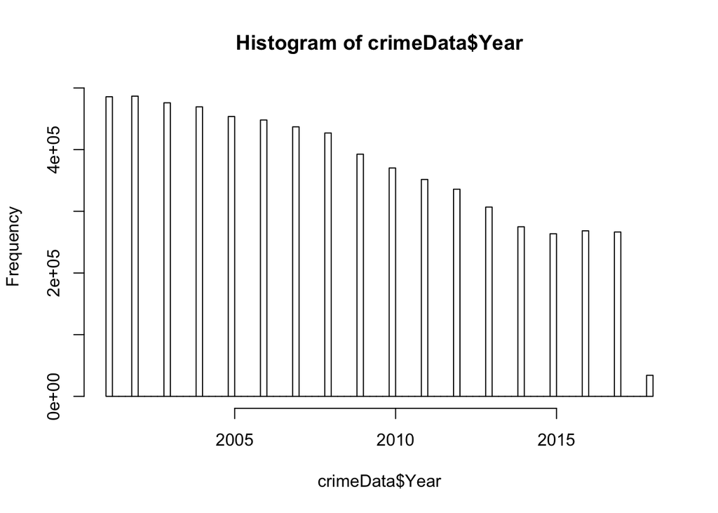

```r
hist(crimeData$Year, breaks = 100)
```

## Data preprocessing

- Focussing analysis on subset of data. As per the plots, it is infered that there is reduction in crime over the years. With huge data available from 2001 to 2018, we are subsetting the data to focus our analysis on recent 10yrs, that is from 2008.

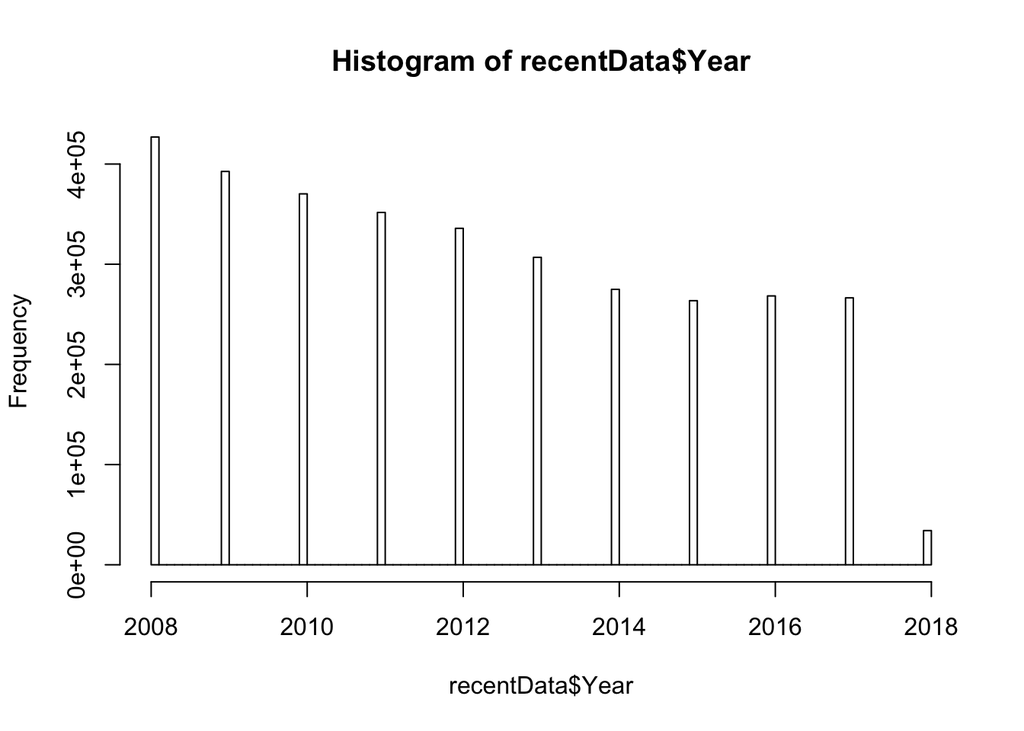

```r
recentData <- subset(crimeData, subset = crimeData$Year > 2007)
recentCrimeData <- recentData
RecentData1<-recentData
Recent1 <- recentData
hist(recentData$Year, breaks = 100)
```

## Analysis on Crime types :

Find the unique “Primary.Type”

```r
unique(recentCrimeData$Primary.Type)
```

```
##  [1] BATTERY                           OTHER OFFENSE
##  [3] ROBBERY                           NARCOTICS
##  [5] CRIMINAL DAMAGE                   WEAPONS VIOLATION
##  [7] THEFT                             BURGLARY
##  [9] MOTOR VEHICLE THEFT               PUBLIC PEACE VIOLATION
## [11] DECEPTIVE PRACTICE                ASSAULT
## [13] CRIMINAL TRESPASS                 CRIM SEXUAL ASSAULT
## [15] INTERFERENCE WITH PUBLIC OFFICER  ARSON
## [17] LIQUOR LAW VIOLATION              KIDNAPPING
## [19] SEX OFFENSE                       OFFENSE INVOLVING CHILDREN
## [21] PROSTITUTION                      HOMICIDE
## [23] GAMBLING                          INTIMIDATION
## [25] STALKING                          OBSCENITY
## [27] PUBLIC INDECENCY                  HUMAN TRAFFICKING
## [29] CONCEALED CARRY LICENSE VIOLATION OTHER NARCOTIC VIOLATION
## [31] NON - CRIMINAL                    NON-CRIMINAL
## [33] NON-CRIMINAL (SUBJECT SPECIFIED)
## 35 Levels: ARSON ASSAULT BATTERY ... WEAPONS VIOLATION
```

## Top 10 crime types from 2008-2018

```r
recentData<-cbind(recentData,quantity=seq(1,1,nrow(crimeData)))
AggrCrime<- aggregate(quantity~Year+Primary.Type,data=recentData,FUN=sum)
AggCrime1<- aggregate(quantity~Primary.Type, data=AggrCrime,FUN=mean)
AggCrime2<- AggCrime1[order(AggCrime1$quantity,decreasing=TRUE),]
top10 <- AggCrime2[1:10,]
top10
```

```
##           Primary.Type quantity
## 32               THEFT 65530.91
## 3              BATTERY 53419.09
## 7      CRIMINAL DAMAGE 33195.64
## 18           NARCOTICS 29177.91
## 4             BURGLARY 18481.82
## 2              ASSAULT 18422.91
## 25       OTHER OFFENSE 18271.18
## 9   DECEPTIVE PRACTICE 13730.45
## 17 MOTOR VEHICLE THEFT 13286.27
## 29             ROBBERY 11909.73
```

Bar Graph Representation of Top Ten Crimes in Recent data

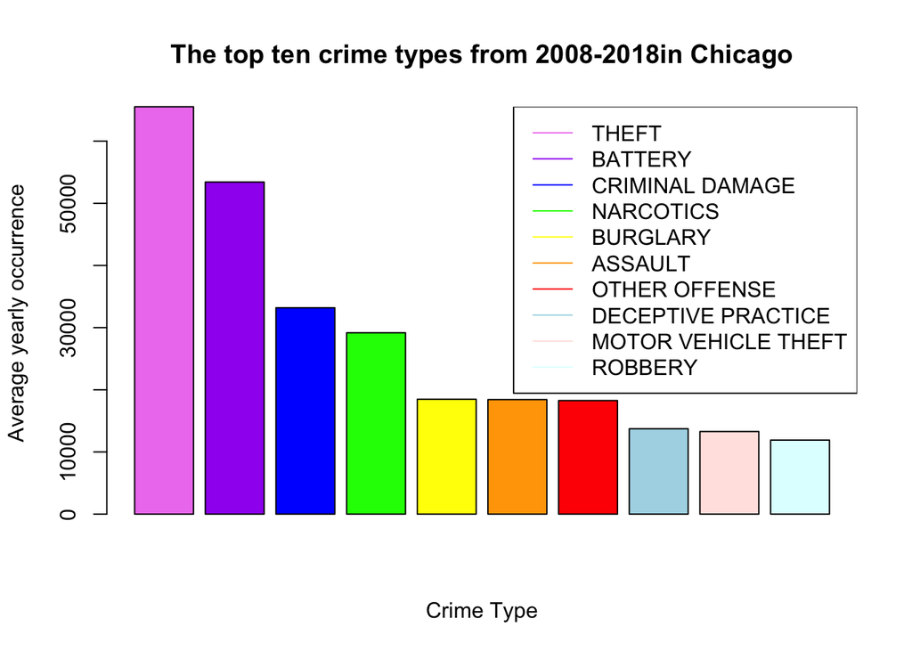

```r
with(top10,barplot(top10$quantity,col=c("violet","purple","blue","green","yellow","orange","red","lightblue","mistyrose","lightcyan"),main="The top ten crime types from 2008-2018in Chicago", xlab="Crime Type",ylab="Average yearly occurrence"))
legend("topright",lty="solid",col=c("violet","purple","blue","green","yellow","orange","red","lightblue","mistyrose","lightcyan"),legend=top10$Primary.Type)
```

## Analysis on Community areas of Chicago.

Least Dangerous Community Areas found by using group_by{dplyr}.

```r
 RecentData2<-RecentData1%>%
  group_by(Community.Area)%>%
  summarise(crime_counts=n())%>%
  arrange(crime_counts)
  RecentData3<-na.omit(RecentData2)
  RecentData3
```

```
## # A tibble: 78 x 2
##    Community.Area crime_counts
##             <int>        <int>
##  1              0           38
##  2              9         3283
##  3             47         4871
##  4             12         5983
##  5             55         7299
##  6             74         7357
##  7             36         7690
##  8             18         7746
##  9             13        10937
## 10             37        10954
## # ... with 68 more rows
```

BarGraph to represent the Top least Dangerous Community Areas

[figure not shown]

```r
areadata <- recentData[which(recentData$Community.Area != ""),]
aggdata_area <- aggregate(quantity~Year+Community.Area,data=areadata,FUN=sum)
aggdata_area2 <- aggregate(quantity~Community.Area,data=aggdata_area,FUN=sum)
aggdata_area2 <- aggdata_area2[order(aggdata_area2$quantity,decreasing=FALSE),]
least3_area <- aggdata_area2[2:4,]
with(least3_area,barplot(least3_area$quantity,col=c("violet","purple","blue","green","yellow","orange","red","lightblue","mistyrose","lightcyan"),main="The top least dangerous community areas in Chicago", xlab="Community area",ylab="Total crime occurrence from 2001-2014"))
legend("topright",lty="solid",col=c("violet","purple","blue","green","yellow","orange","red","lightblue","mistyrose","lightcyan"),legend=least3_area$Community.Area)
```

Analyze the change in occurence of crimes for the top three least dangerous community areas

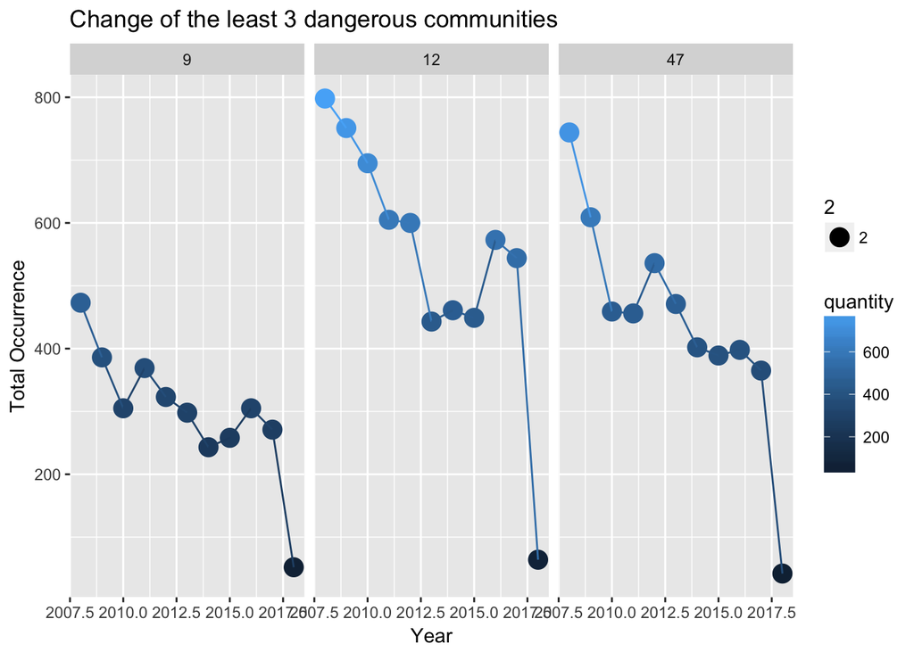

```r
least_area <- aggdata_area2[2:4,]
subaggdata_area2 <- aggdata_area[which(aggdata_area$Community.Area %in% least_area$Community.Area),]

ggplot(data=subaggdata_area2,aes(x=Year,y=quantity)) + facet_grid(.~Community.Area) + geom_point(aes(size=2,col=quantity)) + geom_line(aes(group=1, col=quantity)) + ggtitle("Change of the least 3 dangerous communities") + xlab("Year") + ylab("Total Occurrence")
```

## Analysis on Arrest rates in Districts data

The data is grouped on District and Arrest columns, to find arrest rates in each district.

```r
arrest_count <- Recent1%>% group_by(Recent1$District,Recent1$Arrest)%>%tally()
new_arrest_count <- na.omit(arrest_count)
new_arrest_count
```

```
## # A tibble: 46 x 3
## # Groups:   Recent1$District [23]
##    `Recent1$District` `Recent1$Arrest`      n
##                 <int> <fct>             <int>
##  1                  1 false            100042
##  2                  1 true              32637
##  3                  2 false            106634
##  4                  2 true              32139
##  5                  3 false            124006
##  6                  3 true              43353
##  7                  4 false            146756
##  8                  4 true              45621
##  9                  5 false            108451
## 10                  5 true              38936
## # ... with 36 more rows
```

Graphical representaion of Arrest per District on Stack bar graph.

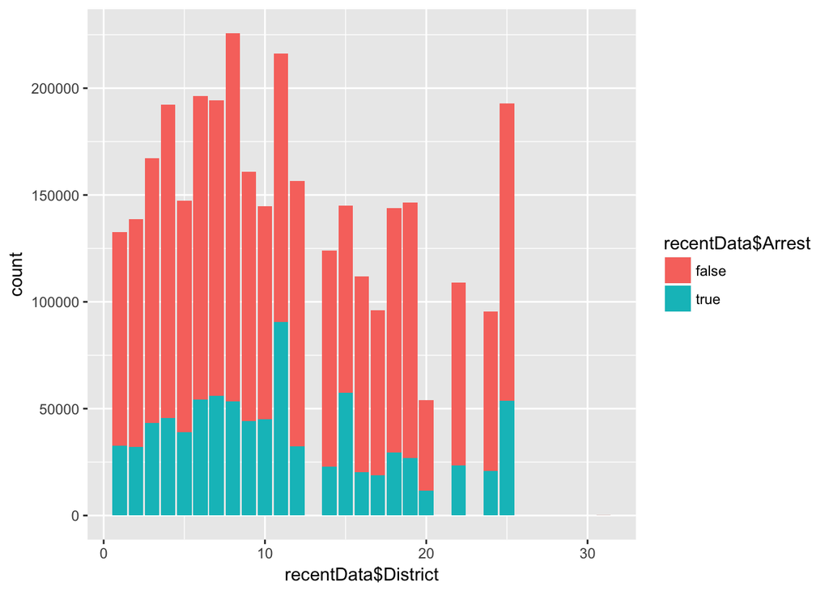

```r
ggplot(data=recentData,aes(recentData$District,fill=recentData$Arrest))+geom_bar()
```

Arrest column has logical values true and false in new_arrest_count dataset. Where true represents arrest, false is no arrest in the district. New dataframe “tf_count” is created to reduce the ambiguity on column names. The data is filtered on Arrest is true.

```r
tf_count <-as.data.frame(new_arrest_count)
 colnames(tf_count)<-c("district_tf","tf_arrest","total_tf")
filter_value_true <- filter(tf_count,tf_arrest=="true")
filter_value_true
```

```
##    district_tf tf_arrest total_tf
## 1            1      true    32637
## 2            2      true    32139
## 3            3      true    43353
## 4            4      true    45621
## 5            5      true    38936
## 6            6      true    54166
## 7            7      true    56134
## 8            8      true    53345
## 9            9      true    44285
## 10          10      true    44986
## 11          11      true    90618
## 12          12      true    32312
## 13          14      true    22936
## 14          15      true    57575
## 15          16      true    20368
## 16          17      true    18787
## 17          18      true    29364
## 18          19      true    26950
## 19          20      true    11488
## 20          22      true    23490
## 21          24      true    20935
## 22          25      true    53634
## 23          31      true       44
```

The data is filtered on Arrest is false

```r
tf_count <-as.data.frame(new_arrest_count)
 colnames(tf_count)<-c("district_tf","tf_arrest","total_tf")
filter_value_false <- filter(tf_count,tf_arrest=="false")
filter_value_false
```

```
##    district_tf tf_arrest total_tf
## 1            1     false   100042
## 2            2     false   106634
## 3            3     false   124006
## 4            4     false   146756
## 5            5     false   108451
## 6            6     false   142122
## 7            7     false   138057
## 8            8     false   172425
## 9            9     false   116621
## 10          10     false    99663
## 11          11     false   125507
## 12          12     false   124268
## 13          14     false   101190
## 14          15     false    87389
## 15          16     false    91426
## 16          17     false    77237
## 17          18     false   114570
## 18          19     false   119531
## 19          20     false    42513
## 20          22     false    85407
## 21          24     false    74570
## 22          25     false   139147
## 23          31     false       69
```

Analysis on Top and Bottom 5 Districts on basis of Arrest

```r
# top 5 districts with arrest = True
filter_value_true[order(filter_value_true$total_tf,decreasing =T )[1:5],]
```

```
##    district_tf tf_arrest total_tf
## 11          11      true    90618
## 14          15      true    57575
## 7            7      true    56134
## 6            6      true    54166
## 22          25      true    53634
```

```r
# bottom 5 district with  arrest= True
filter_value_true[order(filter_value_true$total_tf,decreasing = F)[1:5],]
```

```
##    district_tf tf_arrest total_tf
## 23          31      true       44
## 19          20      true    11488
## 16          17      true    18787
## 15          16      true    20368
## 21          24      true    20935
```

```r
# top 5 district with arrest= false
filter_value_false[order(filter_value_false$total_tf,decreasing = T)[1:5],]
```

```
##    district_tf tf_arrest total_tf
## 8            8     false   172425
## 4            4     false   146756
## 6            6     false   142122
## 22          25     false   139147
## 7            7     false   138057
```

```r
#bottom 5 district with arrest= false
filter_value_false[order(filter_value_false$total_tf,decreasing = F)[1:5],]
```

```
##    district_tf tf_arrest total_tf
## 23          31     false       69
## 19          20     false    42513
## 21          24     false    74570
## 16          17     false    77237
## 20          22     false    85407
```

## Analysis on Crime count in Districts :

. The recent subset data is grouped by disricts to find the district with max and min crimes.

```r
crime_district <- recentCrimeData %>% group_by(recentCrimeData$District) %>% tally()
crime_district <- na.omit(crime_district)
```

District with maximum crime

```r
crime_district$`recentCrimeData$District`[which.max(crime_district$n)]
```

```
## [1] 8
```

District with minimum crime

```r
crime_district$`recentCrimeData$District`[which.min(crime_district$n)]
```

```
## [1] 31
```

Top 5 district with least crime over years:

```r
crime_district <- crime_district[order(crime_district$n),]
head(crime_district, n = 5)
```

```
## # A tibble: 5 x 2
##   `recentCrimeData$District`      n
##                        <int>  <int>
## 1                         31    113
## 2                         20  54001
## 3                         24  95505
## 4                         17  96024
## 5                         22 108897
```

```r
crime_LocationType <- recentCrimeData %>% group_by(recentCrimeData$Location.Description) %>% tally()
crime_LocationType <- na.omit(crime_LocationType)
crime_LocationType <- as.data.frame(crime_LocationType)
names(crime_LocationType) <- c('LocationType', 'count')
r = which.max(crime_LocationType$count)
crime_LocationType[r,]
```

```
##     LocationType  count
## 143       STREET 784205
```

Top 10 most frequent crime location type :

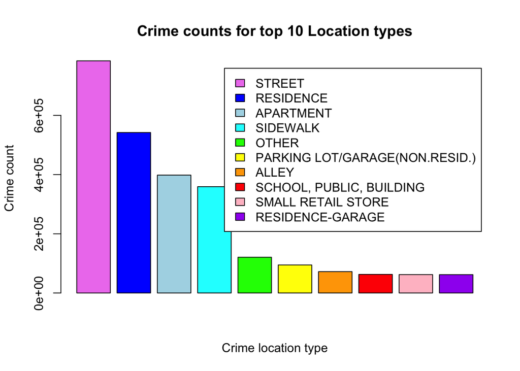

```r
c <- crime_LocationType[order(-crime_LocationType$count),]
c <- head(c,10)
barplot(c$count, col = c("violet","blue", "lightblue","cyan", "green", "yellow","orange","red","pink","purple"),main = "Crime counts for top 10 Location types", xlab = "Crime location type", ylab = "Crime count", legend.text = c$LocationType)
```

Districts crime count for top 10 Location types. From the result obtained for districts having top 10 location types, District 31 is considered safe.

```r
crime_LocationType <- recentCrimeData %>% group_by(recentCrimeData$District, recentCrimeData$Location.Description) %>% tally()
crime_LocationType <- na.omit(crime_LocationType)
crime_LocationType <- as.data.frame(crime_LocationType)
names(crime_LocationType) <- c('District', 'LocationType', 'count')

district <- filter(crime_LocationType, crime_LocationType$LocationType == c("APARTMENT","RESIDENCE", "STREET","SIDEWALK","ALLEY","RESIDENCE-GARAGE","SMALL RETAIL STORE","SCHOOL,PUBLIC,BUILDING"))
district[which.min(district$count),]
```

```
##    District LocationType count
## 21       31       STREET    14
```

```r
crime_districtLocationtype <- recentCrimeData %>% group_by(recentCrimeData$District, recentCrimeData$Location.Description) %>% tally()
crime_districtLocationtype <- na.omit(crime_districtLocationtype)
crimeLocation <- as.data.frame(crime_districtLocationtype)
names(crimeLocation) <- c('District', 'Location', 'count')
crimeLocation2 <- filter(crimeLocation, crimeLocation$District == '31')
```

Most frequently occurred crime location type in district 31

```r
rowNum = which.max(crimeLocation2$count)
crimeLocation2[rowNum,]
```

```
##    District Location count
## 23       31   STREET    14
```

Least frequently occurred crime location type in district 31

```r
rowNum = which.min(crimeLocation2$count)
crimeLocation2[rowNum,]
```

```
##   District Location count
## 9       31 CAR WASH     1
```

## Heat Map of District and Location.

This is a heat map for District and Location of crime, the darker shade of colour in heat map infer that frequency of crime is high in correspondimg district and location type.

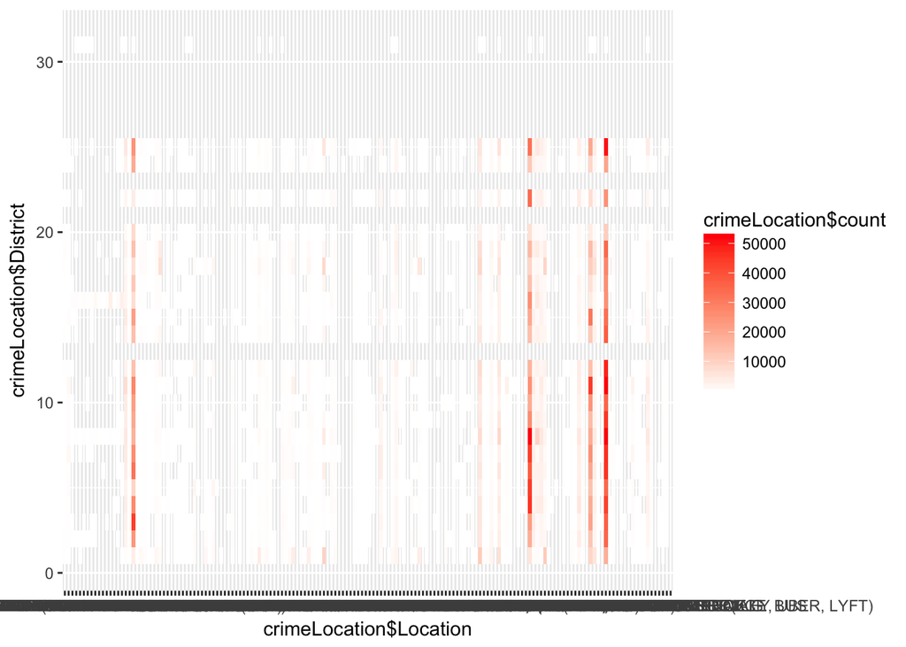

```r
ggplot(crimeLocation, aes(x = crimeLocation$Location, y = crimeLocation$District)) + geom_tile(aes(fill = crimeLocation$count)) + scale_fill_gradient(low="white", high="red")
```

## Stacked bar chart for District vs Primary crime type.

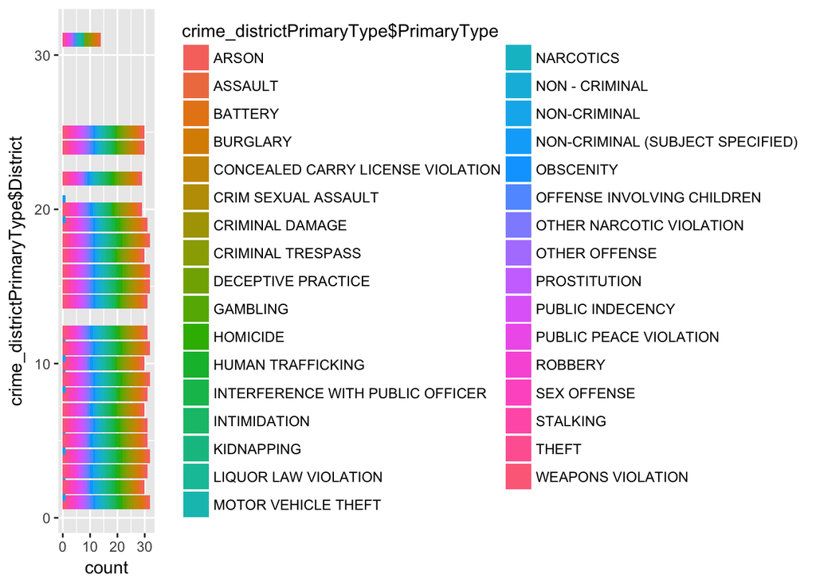

```r
crime_districtPrimaryType <- recentCrimeData %>% group_by(recentCrimeData$District ,recentCrimeData$Primary.Type) %>% tally()
crime_districtPrimaryType <- na.omit(crime_districtPrimaryType)
crime_districtPrimaryType <- as.data.frame(crime_districtPrimaryType)
names(crime_districtPrimaryType) <- c('District', 'PrimaryType', 'count')
ggplot(data = crime_districtPrimaryType, aes(crime_districtPrimaryType$District, fill = crime_districtPrimaryType$PrimaryType)) + geom_bar() + coord_flip()
```

Group by District, LocationType and PrimaryType : The data grouped to find the most primary type of crime in a given loation type and district

```r
crime_LocationTypePrimaryType <- recentCrimeData %>% group_by(recentCrimeData$District, recentCrimeData$Location.Description ,recentCrimeData$Primary.Type) %>% tally()
crime_LocationTypePrimaryType <- na.omit(crime_LocationTypePrimaryType)

crime_LocationTypePrimaryType <- as.data.frame(crime_LocationTypePrimaryType)
names(crime_LocationTypePrimaryType) <- c('District', 'LocationType', 'PrimaryType', 'count')
```

Analysis on District 31 : Primary crime types in District 31 for Location of crime type STREET

```r
filter_district <- filter(crime_LocationTypePrimaryType, crime_LocationTypePrimaryType$District == '31')
filter_type <- filter(filter_district,filter_district$LocationType == "STREET")
filter_type
```

```
##   District LocationType            PrimaryType count
## 1       31       STREET        CRIMINAL DAMAGE     3
## 2       31       STREET      CRIMINAL TRESPASS     1
## 3       31       STREET    MOTOR VEHICLE THEFT     2
## 4       31       STREET              NARCOTICS     6
## 5       31       STREET PUBLIC PEACE VIOLATION     1
## 6       31       STREET                  THEFT     1
```

## Conclusion

On the above results, District 31, Community area 9 are safe for residing and based on the Arrest count and high crime count in District, District 8 is most unsafe to reside.